# Descriptive statistics and data visualisation Foundation Fortnight

Gianluca Baio  
Department of Statistical Science  
University College London  
g.baio@ucl.ac.uk  
http://www.statistica.it/gianluca/  
https://github.com/giabaio

# Summary

- Describing the data
  - Graphical representations
  - Creating a narrative
  - Summary statistics
- Running example
  - Child mortality rates etc
  - Various graphical depctions + summarising the data
- Fun with dinosaurs

### References

> Irizarry (2020). *[Introduction to Data Science — Data Analysis and Prediction Algorighms with R](https://rafalab.github.io/dsbook/)*, chapters 9, 7, 8, 10, 11

> Spiegelhalter (2019). *[The Art of Statistics. Learning from Data](https://www.penguin.co.uk/books/294/294857/learning-from-data/9780241258767.html)*.

> Wickham and Grolemund (2017). *[R for data science](https://www.tidyverse.org/learn/)*

> Wickham (2016). *[ggplot2: Elegant graphics for data analysis](https://ggplot2-book.org/)*

# What’s this all about?…

- Broadly speaking, the objective of statistical analysis is to produce “some summary” of the available data
- Sometimes, it is at least theoretically possible to deal with an entire population of observable quantities (e.g. census). In this case, **every** unit is measured and we can produce some *descriptive* statistics
  - Mean height of population
  - Standard deviation of age
- However, in most cases measuring a whole population is impossible or extremely difficult
  - *Economic reasons*: to measure many units might be very expensive
  - *Accuracy reasons*: sometimes it is better to measure very precisely just some units instead of measuring very imprecisely many units
  - *Physical reasons*: sometimes the very measurement destroys the unit (e.g. time to death)
- Therefore we need to rely on a **subset of individuals** (units) for which a measurement is indeed available, and make *inference* about the unobservable overall population

# EXAMPLE: Which country has the highest child mortality rates?

*For each of the five pairs of countries below, which do you think has the highest child mortality rates in 2015?*

1. Sri Lanka or Turkey?
2. Poland or South Korea?
3. Malaysia or Russia?
4. Pakistan or Vietnam?
5. Thailand or South Africa?

**Intuition**: “Western” countries are characterised by long life span and small families, while the “developing” world has short life span and large families. BUT: do they?…

The late Swedish epidemiologist [Hans Rosling](https://en.wikipedia.org/wiki/Hans_Rosling) (the founder of [Gapminder](https://www.gapminder.org/)) used this question in one of his videos (“New insights on poverty” — https://tinyurl.com/yxk79qms)

# Which country has the highest child mortality rates?

```r
> library(tidyverse)                # loads the R "environment" (tidyverse), a collection of useful packages
> library(dslabs)                   # loads the R package containing the data
> library(DT)                       # loads the R package to visualise tables
> data(gapminder)                   # loads the data into the current workspace
> gapminder %>% datatable()         # visualises the dataset (allows some filtering & searching, using 'DT')
```

| country | year | infant_mortality | life_expectancy | fertility | population | gdp | continent | region |
| --- | --- | --- | --- | --- | --- | --- | --- | --- |
| Albania | 1960 | 115.4 | 62.87 | 6.19 | 1636054 |  | Europe | Southern Europe |
| Algeria | 1960 | 148.2 | 47.5 | 7.65 | 11124892 | 13828152297 | Africa | Northern Africa |
| Angola | 1960 | 208 | 35.98 | 7.32 | 5270844 |  | Africa | Middle Africa |
| Antigua and Barbuda | 1960 |  | 62.97 | 4.43 | 54681 |  | Americas | Caribbean |
| Argentina | 1960 | 59.87 | 65.39 | 3.11 | 20619075 | 108322326649 | Americas | South America |
| Armenia | 1960 |  | 66.86 | 4.55 | 1867396 |  | Asia | Western Asia |
| Aruba | 1960 |  | 65.66 | 4.82 | 54208 |  | Americas | Caribbean |
| Australia | 1960 | 20.3 | 70.87 | 3.45 | 10292328 | 96677859364 | Oceania | Australia and New Zealand |
| Austria | 1960 | 37.3 | 68.75 | 2.7 | 7065525 | 52392699681 | Europe | Western Europe |
| Azerbaijan | 1960 |  | 61.33 | 5.57 | 3897889 |  | Asia | Western Asia |

[output cut: 10535 more lines]

# Which country has the highest child mortality rates?

### What’s going on?

Some of these results (expressed as infant deaths per 1000 births) may surprise you…

```
    country infant_mortality
1 Sri Lanka              8.4
2    Turkey             11.6
```

```
      country infant_mortality
1 South Korea              2.9
2      Poland              4.5
```

```
   country infant_mortality
1 Malaysia              6.0
2   Russia              8.2
```

```
   country infant_mortality
1 Pakistan             65.8
2  Vietnam             17.3
```

```
       country infant_mortality
1 South Africa             33.6
2     Thailand             10.5
```

so perhaps need to investigate further…

- Use *longitudinal* nature of the data — observations from the time series (past years)
  - NB: can do this in many ways…

# Which country has the highest child mortality rates?

### Data from the past (NB: each dot is one of the countries in the dataset)

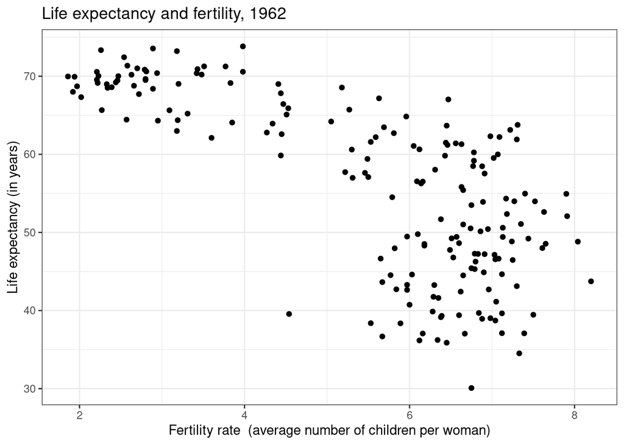

# Which country has the highest child mortality rates?

### Many components?

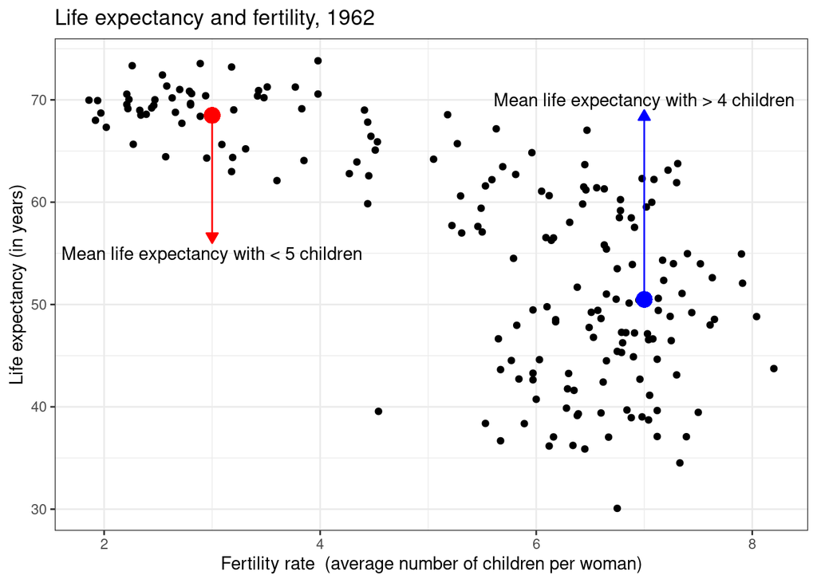

# Which country has the highest child mortality rates?

### Trends

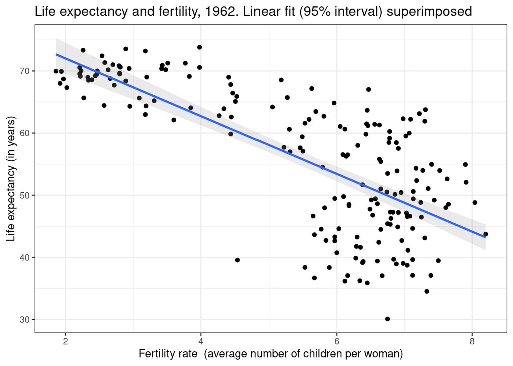

# Which country has the highest child mortality rates?

### Trends

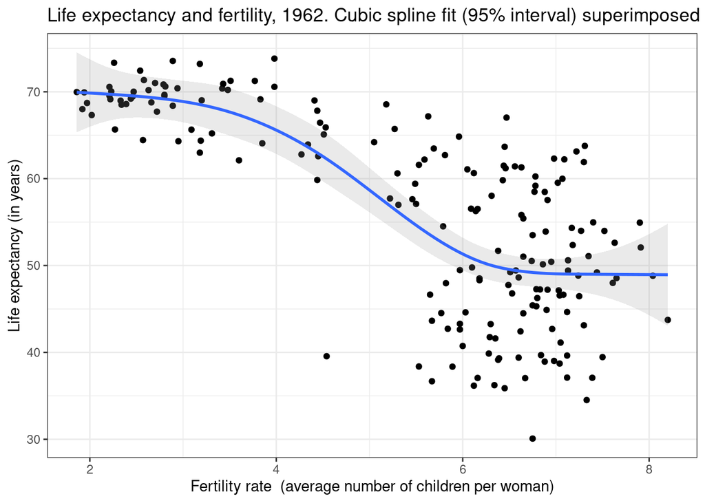

# Which country has the highest child mortality rates?

### Or even more?…

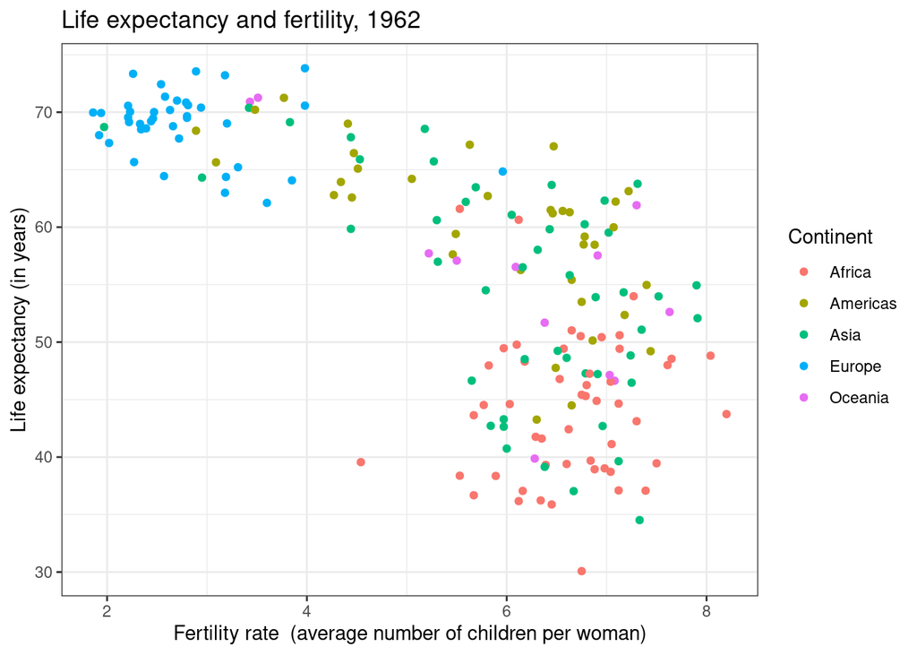

# Which country has the highest child mortality rates?

## Let’s take stock for a moment…

### Technical comments

- Trends can be tricky to spot — we may think that a linear decrease is reasonable, but probably, once we tried, we’d be happier with a smoother, non-linear trend
  - Basically, we do not know — so it’s a good thing to test various **assumptions**!
- It’s a good idea to show the same data under different perspectives
  - For instance, with and without grouping by continent to see if we can gain some more insight into the features of the data generating process

### Substantive comments

- The analysis of the historical data (**from 1962**, in this case) seems to confirm the intuition that, indeed, “western” countries (eg in Europe and North America) do have smaller families and longer life expectancy
- And indeed “developing” countries (eg in Africa, Asia and Latin America) tend to have shorter life expectancy with larger families
- So there must be something that over time has modified these patterns…
- Can we explore further?

# Comparisons over time and space

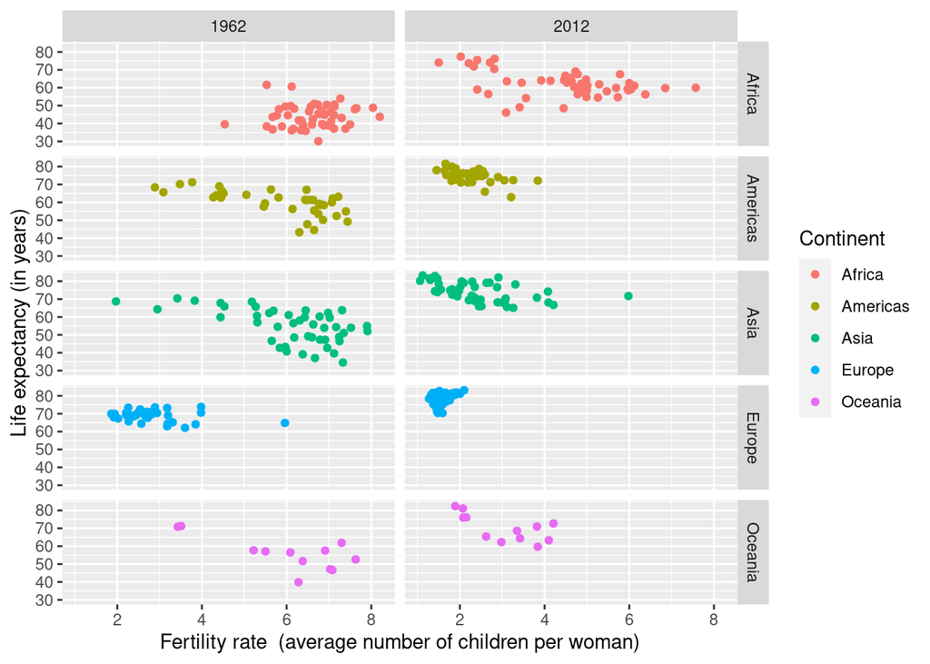

# Comparisons over time and space

Asian countries have generally improved at a much faster rate than European ones

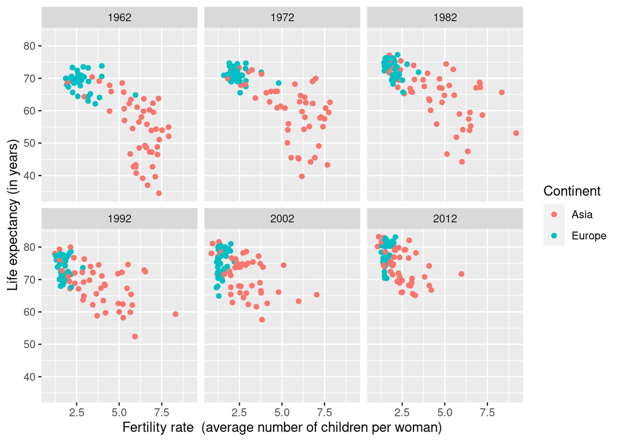

# Comparisons over time and space

### The importance of scaling!

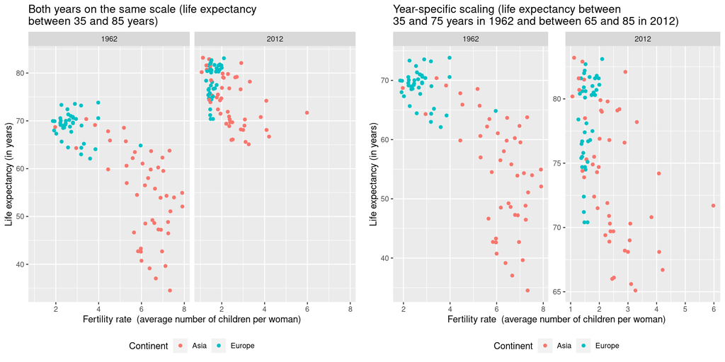

NB: The plots on the right hand side appear **artificially** similar because of the different scale on the $y$-axis!

# Comparisons over time and space

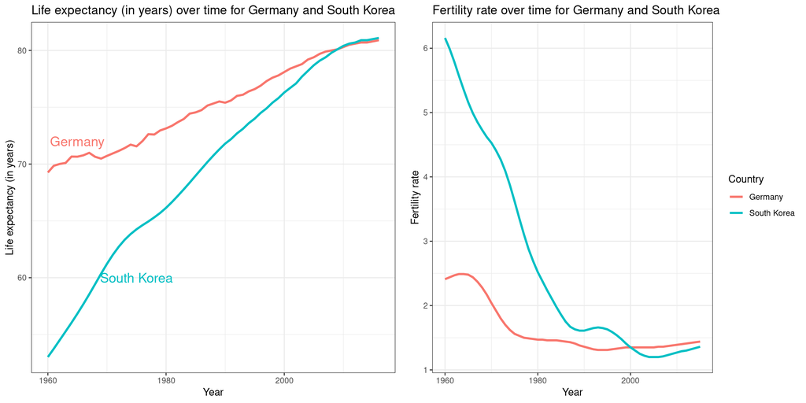

- Plotting time series is often a good way of depicting the overall trend
- But we can’t always read too much into the graph (because there may be factors making the comparison not meaningful, unless we do some modelling!… — more on this later)

# Data transformations & summaries

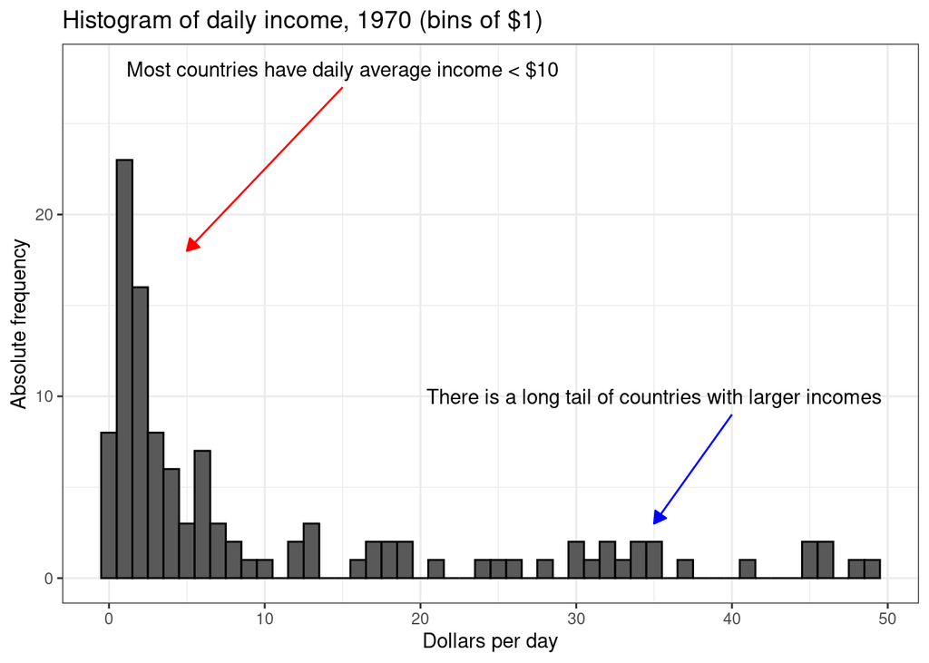

# Data transformations & summaries

### The importance of “binning”

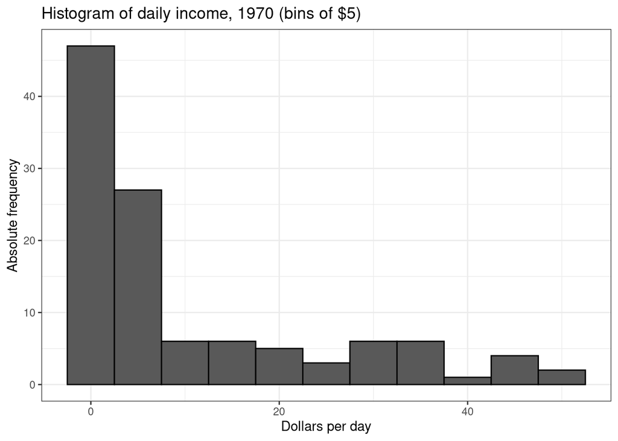

# Data transformations & summaries

- This graph shows that the empirical sampling distribution of the data is highly **skewed**
  - A large number of units is highly concentrated on small values of the outcome, but there are also many units who have a single, larger value
  - This is interesting because this *descriptive* analysis can be used to inform our modelling — a Normal distribution (eg a linear model) is certainly not a great idea!
- It may be a good idea to rescale/transform the data to make more sense of them
  - Can think in terms of progression of income:
    1. $1 = extremely poor
    2. $2 = very poor
    3. $4 = poor
    4. $8 = middle
    5. $16 = well off
    6. $32 = rich
    7. $64 = very rich
  - This naturally links to logarithms (in base 2)
- In any case, a histogram is still a representation of the data based on assumptions (eg binning) — not the “truth” (if such thing could ever exist…)

# Data transformations & summaries

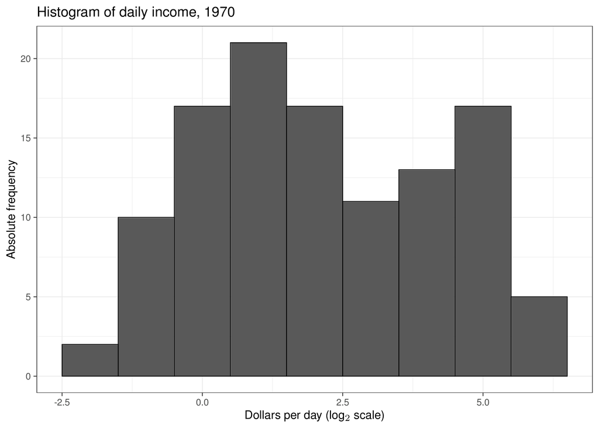

# Data transformations & summaries

Graphs are a good way to summarise the data, but often we want to have some **numerical** summary to convey the information

### Measures of Location (or level)

$$\displaystyle\textsf{Arithmetic mean: }\color{blue}{\mu = \sum_{i=1}^N \frac{y_i}{N}}$$

$$\textsf{Median: } \color{blue}{\textsf{Med}(Y) = \left\{\!\!
\begin{array}{lcl}
\textsf{the $\frac{N+1}{2}$-th observation} & & \textsf{if $N$ is odd} \\
\textsf{the $\frac{N}{2}$-th observation} & & \textsf{if $N$ is even}
\end{array}\right.}$$

$$\textsf{Quantiles: } \color{blue}{y_q \textsf{ on the data scale such that } \Pr(Y\leq y_{q})\geq q}$$

### Measures of Spread (or dispersion)

$$\textsf{Range: } \color{blue}{\max(Y)-\min(Y)}$$

$$\textsf{Interquartile range: IQR} = \color{blue}{y_U-y_L, \quad\textsf{where} \left\{\!\!\begin{array}{l} y_U: \Pr(Y\leq y_U)\geq 0.75 \\ y_L: \Pr(Y\leq y_L)\geq 0.25\end{array}\right.}$$

$$\displaystyle\textsf{Variance: } \color{blue}{\sigma^2=\sum_{i=1}^N \frac{(y_i-\mu)^2}{N}}$$

NB: Standard deviation: $\sigma=\sqrt{\sigma^2}$ is on the same scale as the data

# Data transformations & summaries

### Mean vs median

```r
> gapminder %>% filter(year==1970 & !is.na(gdp)) %>%
+   summarise(mean=mean(dollars_per_day),median=median(dollars_per_day))
```

```
      mean   median
1 10.70525 3.717227
```

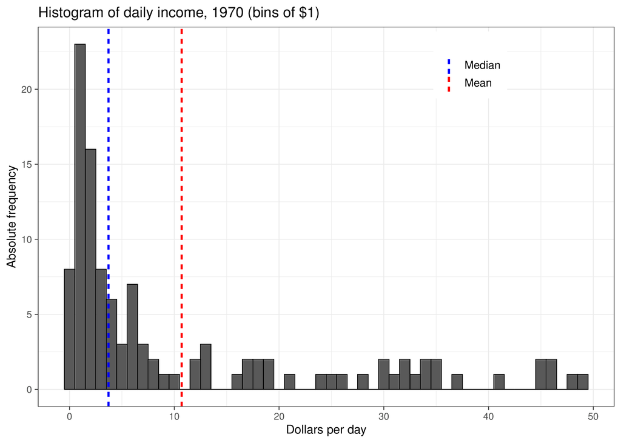

# Comparing multiple distributions

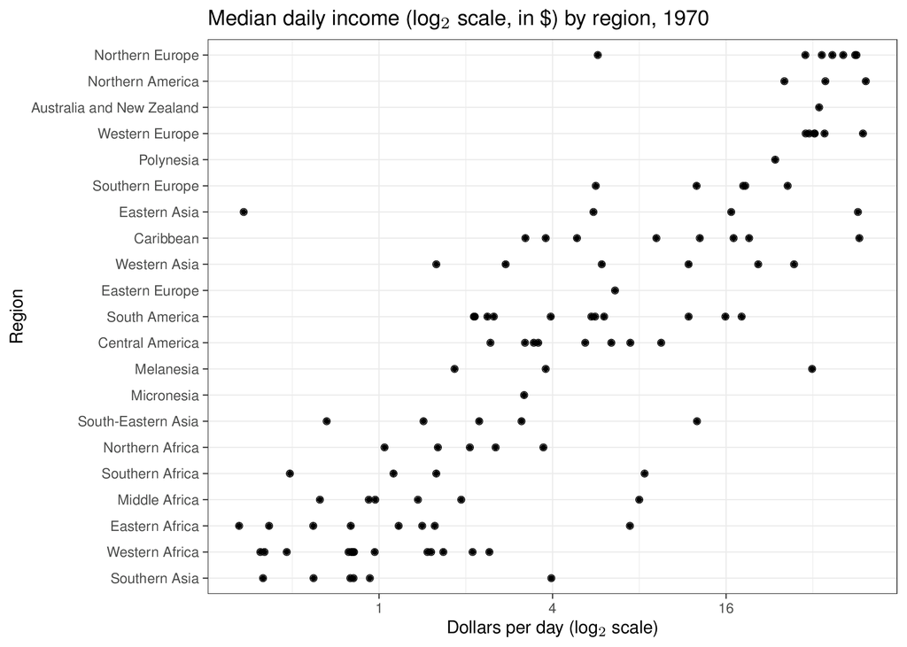

# Comparing multiple distributions

# Comparing multiple distributions

### Boxplots

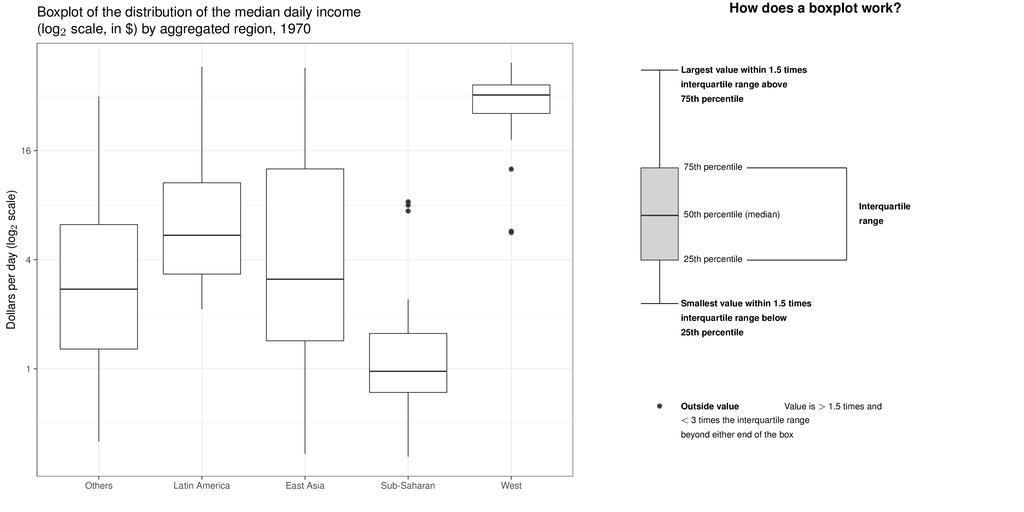

# Comparing multiple distributions

### Boxplots

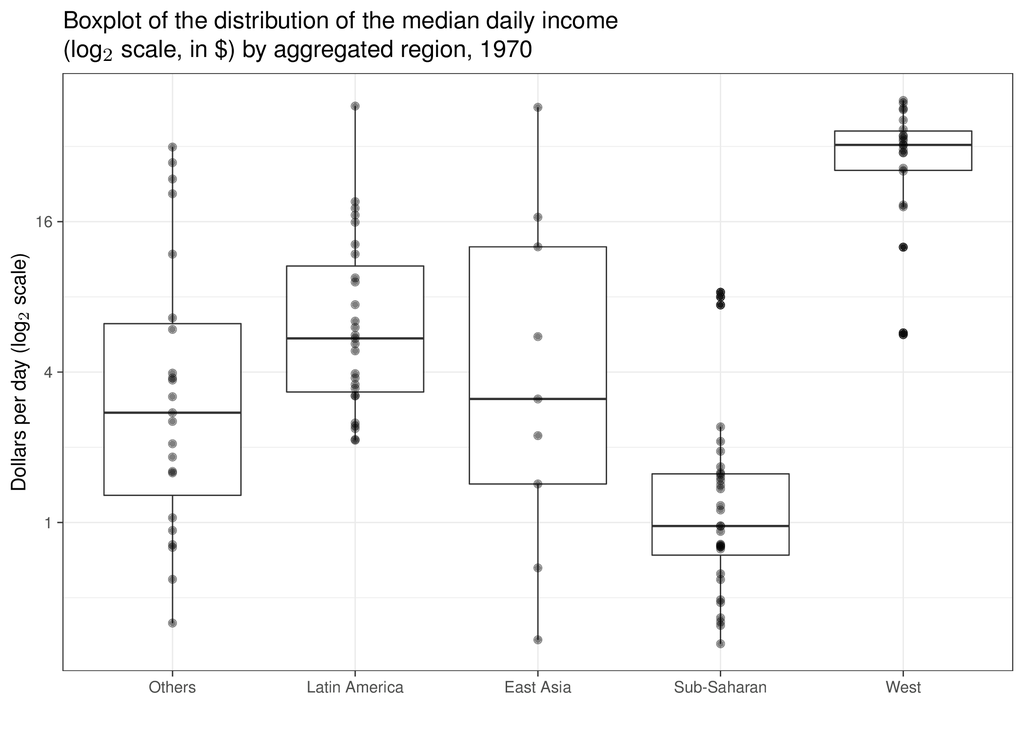

NB: Sometimes it may be a good idea to overlay the whole distribution of points on top of the boxplot

# Comparing multiple distributions

### AKA Joyplots — (https://tinyurl.com/yyquhoht)

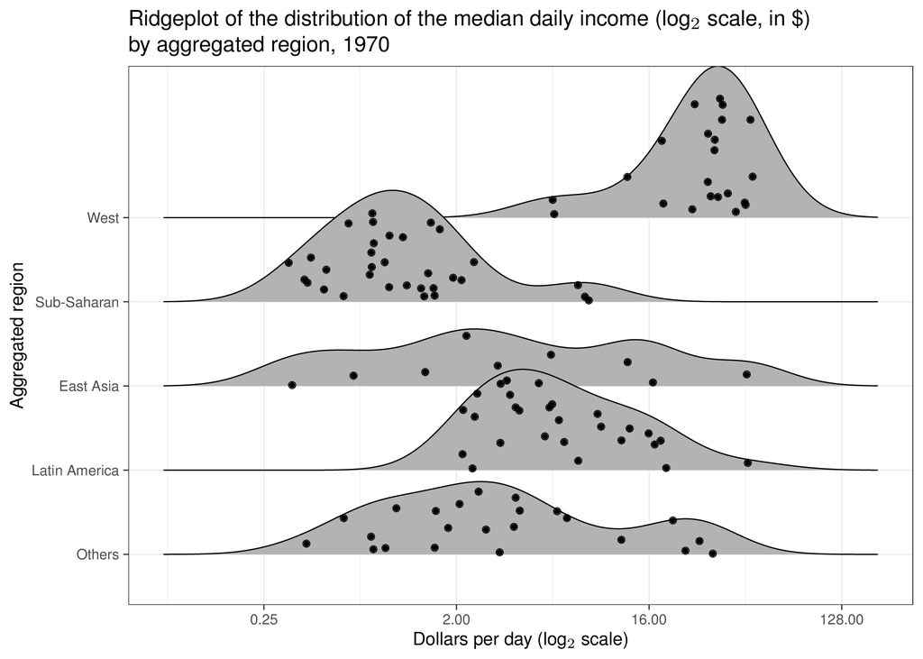

# Comparing multiple distributions

### Don’t always log…

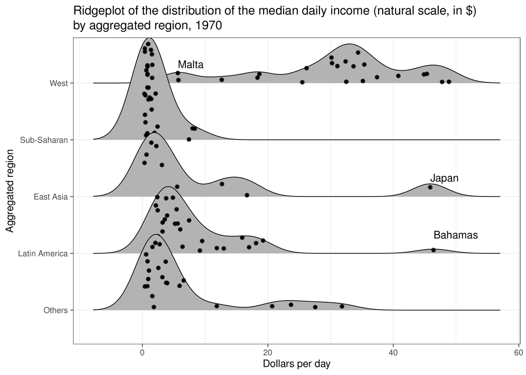

# Comparing multiple distributions

- Re-scaling the data on the log has several advantages
  - “Stretches” the data, so differences are easier to spot
  - Makes data more symmetrical, so Normality more plausible (so can use simpler methods, eg linear regression)
  - Stabilises numerical computation (as values that are “too big” are scaled down)
- **BUT**: sometimes we may be missing out on some important features in the natural scale
  - Direct interpratation of the values — with the natural scale we can see exactly what level of income we are talking about!
  - Can appreciate spread of variables — some “West” countries have incomes that are as low as many of the poorer areas; similarly, there are “outliers” in “East Asia” and “Latin America”, which are just as rich as the richest countries

# Comparing multiple distributions

### …over time

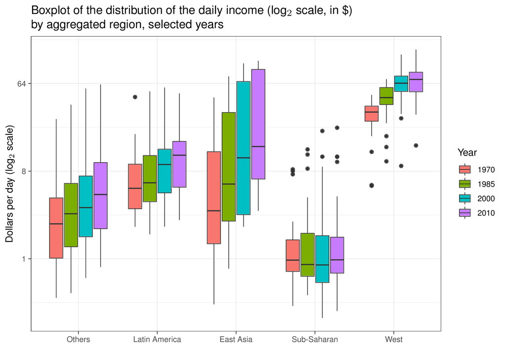

# Comparing multiple distributions

### Space for one more?…

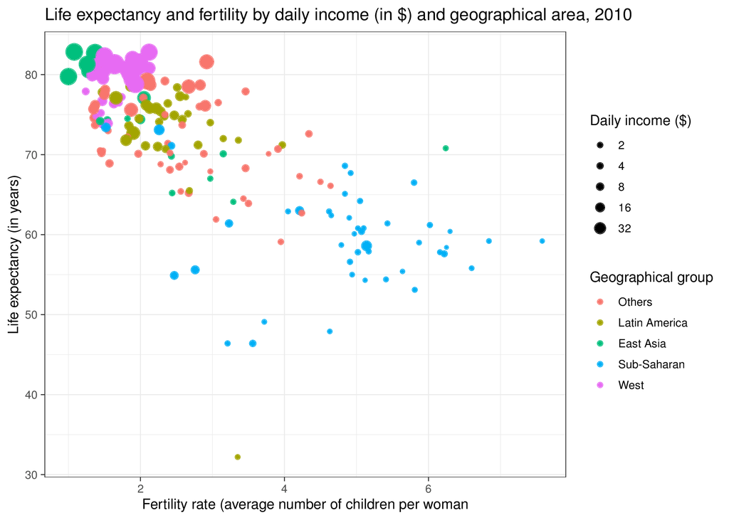

# Confounding

### Don’t trust the data at face value…

- We need to be careful to take summary/descriptive statistics or visualisation at face value!
- There are many classical examples of “confounding” in many applications
  - “Effects” can be masked/modified by variables that we do not observe
  - Phenomena such as **“Simpson’s Paradox”**: exposure to a health condition is not bad for men and is not bed for women. But it’s bad when we observe the whole population
- For example, suppose you observe the following data

| Exposure | Disease | No disease | Risk |
| --- | --- | --- | --- |
| Exposed | 81 | 29 | =81/(81+29)=0.7364 |
| Not exposed | 28 | 182 | =28/(28+182)=0.1333 |

$$\textsf{Relative risk} = \frac{0.7364}{0.1333}=5.52$$

- We might conclude that exposure to a certain risk factor increases highly the chances of getting a disease
- In fact, exposed people are over 5 times more likely to get the disease

# Confounding

### Don’t trust the data at face value…

- Now imagine that we can actually observe a third variable (eg sex)

| Exposure | Sex=Male Disease | Sex=Male No disease | Sex=Male Risk | Sex=Female Disease | Sex=Female No disease | Sex=Female Risk |
| --- | --- | --- | --- | --- | --- | --- |
| Exposed | 1 | 9 | 0.1 | 80 | 20 | 0.8 |
| Non exposed | 20 | 180 | 0.1 | 8 | 2 | 0.8 |
| Relative risk |  |  | 1.0 |  |  | 1.0 |

- If we “control” for sex, it appears that there is no effect at all (the relative risks are the same for exposed and non exposed in both groups)
- How is that paradox possible?

# Confounding

### Don’t trust the data at face value…

- The explanation of the paradox is in the fact that sex (the confounder) is **associated with the risk factor**

| Exposure | Sex=Male Disease | Sex=Male No disease | Sex=Male Risk | Sex=Female Disease | Sex=Female No disease | Sex=Female Risk |
| --- | --- | --- | --- | --- | --- | --- |
| Exposed | 1 | 9 | 0.1 | 80 | 20 | 0.8 |
| Non exposed | 20 | 180 | 0.1 | 8 | 2 | 0.8 |
| Relative risk |  |  | 1.0 |  |  | 1.0 |

$$\textsf{RR}_{\text{F}/\text{M}} = \frac{88/(88+22)}{21/(21+189)}=8$$

- The disease is 8 times more likely to occur in females than in males
- But, in the sample:
  - The majority of exposed people are female (**100** vs **10**), who are at greater risk of getting the disease
  - The majority of not exposed are male (**200** vs **10**), who are a lower risk
- This explains the paradox!

# All that glitters…

Descriptive statistics & visualisation can be deceptive…

```r
> # Loads Alberto Cairo's 'datasaurus' collection of datasets: https://www.autodeskresearch.com/publications/samestats
> datasaurus=read.csv("DatasaurusDozen.tsv",sep="\t") %>% as_tibble()
```

| Dataset | X Mean | X SD | X Min | X Median | X Max | Y Mean | Y SD | Y Min | Y Median | Y Max | Corr |
| --- | --- | --- | --- | --- | --- | --- | --- | --- | --- | --- | --- |
| bullseye | 54.26873 | 16.76924 | 19.28820 | 53.84209 | 91.73554 | 47.83082 | 26.93573 | 9.6915471 | 47.38294 | 85.87623 | -0.0685864 |
| dino | 54.26327 | 16.76514 | 22.30770 | 53.33330 | 98.20510 | 47.83225 | 26.93540 | 2.9487000 | 46.02560 | 99.48720 | -0.0644719 |
| slant_down | 54.26785 | 16.76676 | 18.10947 | 53.13516 | 95.59342 | 47.83590 | 26.93610 | 0.3038724 | 46.40131 | 99.64418 | -0.0689797 |
| slant_up | 54.26588 | 16.76885 | 20.20978 | 54.26135 | 95.26053 | 47.83150 | 26.93861 | 5.6457775 | 45.29224 | 99.57959 | -0.0686092 |

- All datasets show more or less the same values for the summary statistics of the two variables $X$ and $Y$
- In all cases, the Pearson correlation between $X$ and $Y$ (measuring linear association between two variables) is vitually 0
  - **BUT**: no correlation can come from a random scatter of points, or any other pattern with no systematic trend (either up- or downwards)…

# All that glitters…

Descriptive statistics & visualisation can be deceptive…

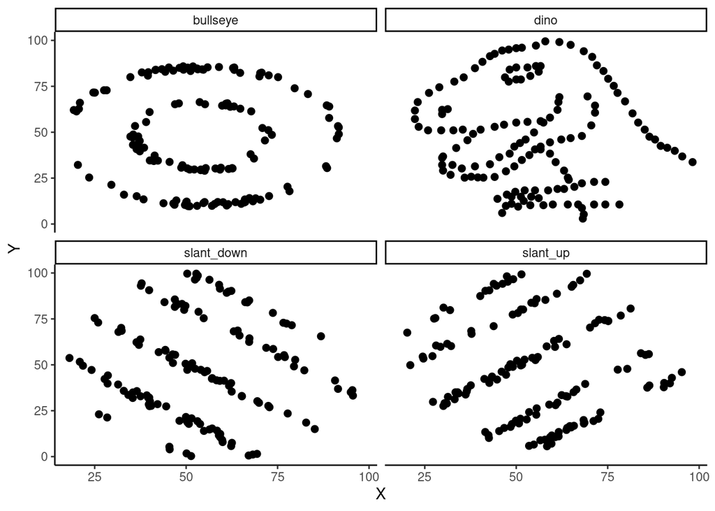

Thank you!